# Unidad 2

### ANOVA

El análisis de la varianza es un herramienta que se usa para estudiar diferencias en al media entre dos o más grupos, definidos por una variables aleatoria categórica.

Si hay una solos grupo de varaibles aleatorias, se dice que el análisis es de una vía (*One-way ANOVA*), en cambio si hay dos grupos de variable aleatorias es un análisis de dos vías (*Two-way ANOVA*).

#### Premisas

- Cada factor es aleatorio e independiente.
- Los valores están normalmente distribuidos.
- Las varianzas son iguales.

### ANOVA de una vía

Construyamos un pequeño conjunto de datos para el ejemplo.

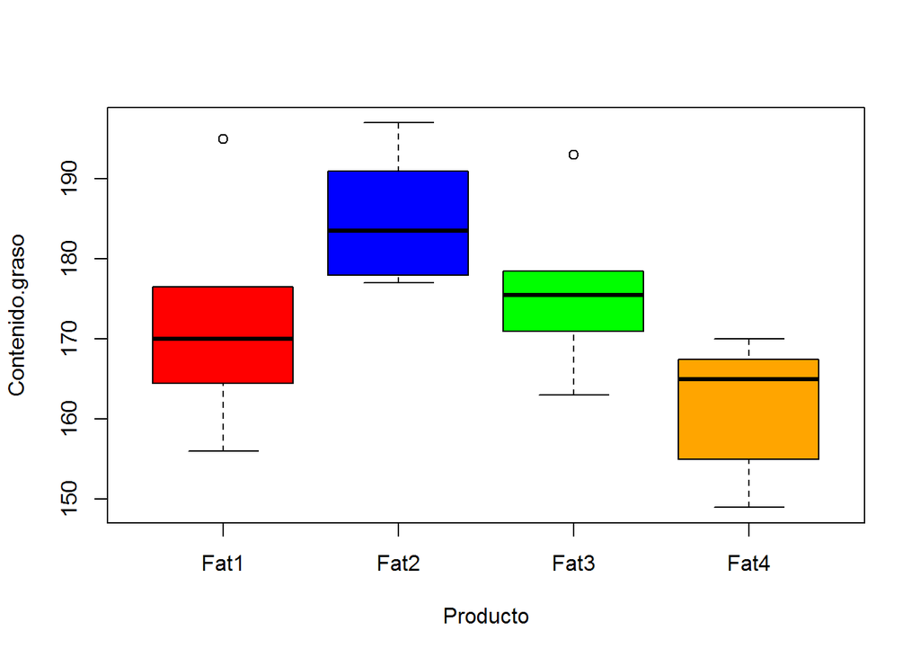

```r
Fat1 <- c(164.5, 172, 168, 176.5, 156, 195)
Fat2 <- c(178, 191, 197, 182, 185, 177)
Fat3 <- c(175, 193, 178.5, 171, 163, 176)
Fat4 <- c(155, 166, 149, 164, 170, 167.5)
donuts <- data.frame(
  "Contenido.graso"=c(Fat1, Fat2, Fat3, Fat4),
  "Producto"=rep(c("Fat1", "Fat2", "Fat3", "Fat4"), each=6)
)

boxplot(
  Contenido.graso ~ Producto,
  data=donuts,
  col=c("red", "blue", "green", "orange")
)
```

```r
shapiro.results <- aggregate(
  Contenido.graso~Producto,
  data=donuts,
    compose(
    function(x) {x[[2]]}, # Extrae el p-value
    shapiro.test
  )
)

shapiro.results
```

```
##   Producto Contenido.graso
## 1     Fat1       0.7001935
## 2     Fat2       0.5926485
## 3     Fat3       0.6709227
## 4     Fat4       0.3143462
```

```r
anova_result <- aov(
  formula=Contenido.graso~Producto,
  data=donuts)

summary(anova_result)
```

```
##             Df Sum Sq Mean Sq F value  Pr(>F)
## Producto     3   1651   550.2   5.497 0.00641 **
## Residuals   20   2002   100.1
## ---
## Signif. codes:  0 '***' 0.001 '**' 0.01 '*' 0.05 '.' 0.1 ' ' 1
```

```r
pval <- summary(anova_result)[[1]]$"Pr(>F)"[1]
pval
```

```
## [1] 0.00640605
```

```r
my_model <- lm(
   formula=Contenido.graso~Producto,
  data=donuts
)

summ_model <- summary(my_model)
summary(my_model)
```

```
##
## Call:
## lm(formula = Contenido.graso ~ Producto, data = donuts)
##
## Residuals:
##      Min       1Q   Median       3Q      Max
## -16.0000  -6.9375  -0.0417   4.7708  23.0000
##
## Coefficients:
##              Estimate Std. Error t value Pr(>|t|)
## (Intercept)   172.000      4.084  42.111   <2e-16 ***
## ProductoFat2   13.000      5.776   2.251   0.0358 *
## ProductoFat3    4.083      5.776   0.707   0.4878
## ProductoFat4  -10.083      5.776  -1.746   0.0962 .
## ---
## Signif. codes:  0 '***' 0.001 '**' 0.01 '*' 0.05 '.' 0.1 ' ' 1
##
## Residual standard error: 10 on 20 degrees of freedom
## Multiple R-squared:  0.4519, Adjusted R-squared:  0.3697
## F-statistic: 5.497 on 3 and 20 DF,  p-value: 0.006406
```

```r
pf(
  q = summ_model$fstatistic["value"],
  df1 = summ_model$fstatistic["numdf"],
  df2 = summ_model$fstatistic["dendf"],
  lower.tail = FALSE)
```

```
##      value
## 0.00640605
```

### Corrección por comparación múltiple

Los procedimientos de comparación múltiple se usan comunmente después de obtener un resultado de ANOVA que muestra alguna diferencia entre grupos.

Para determinar que grupo/grupos son diferenciales, hay que hacer comparaciones de a pares. Si tenes N grupos, entonces hay
$$\frac{N \times (N-1)}{2}$$
pares que hacer.

Los procedimientos de comparación múltiple se pueden entender como una correción de los p-value obtenidos.

#### Bonferroni

En la corrección de Bonferroni, los p-values se multiplican por el número de comparaciones.

```r
pairwise.t.test(
  x=donuts$Contenido.graso,
  g=donuts$Producto,
  data=donuts,
  p.adjust.method = "bonferroni"
)
```

```
##
##  Pairwise comparisons using t tests with pooled SD
##
## data:  donuts$Contenido.graso and donuts$Producto
##
##      Fat1   Fat2   Fat3
## Fat2 0.2149 -      -
## Fat3 1.0000 0.8301 -
## Fat4 0.5773 0.0043 0.1409
##
## P value adjustment method: bonferroni
```

#### Tukey’s HSD (Honestly significant difference)

Otra de los procedimientos de comparación multiple es la prueba de Tukey-HSD. Esta prueba se basa en la distribución de Tukey (tambíen conocida como *Studentized Range Distribution*). Esta distribución considera tomar $k$ muestras de tamaño $n$ de una distribución normal. $Y_{max}$ es la media máxima y $Y_{min}$ es la media mínima entre las k muestras. Entonces el estadístico q toma la distribución de Tukey.

En base a esta distribución se calcula, para todos los pares de grupos en nuestros datos, un valor crítico q:

$$q_c = \frac{\bar{Y_A} - \bar{Y_A}}{SE} \\
SE = \sqrt{\frac{\sum_{G \in Grupo}{var(G)}}{N}}$$

```r
means_product <- aggregate(
  Contenido.graso ~ Producto,
  data=donuts,
  mean
)
rownames(means_product) <- means_product$Producto

# Diferencia entre el grupo Fat2 y Fat4
ydiff <- abs(
  means_product["Fat2", "Contenido.graso"]-
  means_product["Fat4", "Contenido.graso"]
)

N <- nrow(donuts) # Cantidad de muestras
k <- length(unique(donuts$Producto)) # Cantidad de grupos
n <- N/k # Muestras por grupo

# Calculo el Error Standard
se <- sum(
  aggregate(
    Contenido.graso~Producto,
    data=donuts,
    FUN=var
    )$Contenido.graso
  )
se <- sqrt(se/N)

# Calculo el valor crítico de Q
qvalue <- ydiff/se

# Calculo el p-value.
ptukey(
  qvalue,
  nmeans = 4,
  lower.tail = FALSE,
  df=20
)
```

```
## [1] 0.003646508
```

```r
TukeyHSD(anova_result)
```

```
##   Tukey multiple comparisons of means
##     95% family-wise confidence level
##
## Fit: aov(formula = Contenido.graso ~ Producto, data = donuts)
##
## $Producto
##                 diff        lwr       upr     p adj
## Fat2-Fat1  13.000000  -3.167407 29.167407 0.1438609
## Fat3-Fat1   4.083333 -12.084073 20.250740 0.8931650
## Fat4-Fat1 -10.083333 -26.250740  6.084073 0.3275931
## Fat3-Fat2  -8.916667 -25.084073  7.250740 0.4315888
## Fat4-Fat2 -23.083333 -39.250740 -6.915927 0.0036465
## Fat4-Fat3 -14.166667 -30.334073  2.000740 0.0990780
```

### Prueba de Kruskal-Wallis

Este prueba es una alternativa no paramétrica para el análisis de varianza. Es una generalización de la prueba de Wilcoxon para comparar dos distribuciones.

```r
kruskal.test(
  x = donuts$Contenido.graso,
  g = donuts$Producto
)
```

```
##
##  Kruskal-Wallis rank sum test
##
## data:  donuts$Contenido.graso and donuts$Producto
## Kruskal-Wallis chi-squared = 12.087, df = 3, p-value = 0.007092
```

#### Corrección por comparación múltiple

```r
posthoc.kruskal.nemenyi.test(
  x=donuts$Contenido.graso,
  g=donuts$Producto,
  dist="Tukey"
  )
```

```
##
##  Pairwise comparisons using Tukey and Kramer (Nemenyi) test
##                    with Tukey-Dist approximation for independent samples
##
## data:  donuts$Contenido.graso and donuts$Producto
##
##      Fat1   Fat2   Fat3
## Fat2 0.1878 -      -
## Fat3 0.9406 0.4812 -
## Fat4 0.4812 0.0034 0.1878
##
## P value adjustment method: none
```

```r
posthoc.kruskal.nemenyi.test(
  x=donuts$Contenido.graso,
  g=donuts$Producto,
  dist="Chisq"
  )
```

```
##
##  Pairwise comparisons using Nemenyi-test with Chi-squared
##                        approximation for independent samples
##
## data:  donuts$Contenido.graso and donuts$Producto
##
##      Fat1   Fat2   Fat3
## Fat2 0.2613 -      -
## Fat3 0.9549 0.5638 -
## Fat4 0.5638 0.0083 0.2613
##
## P value adjustment method: none
```

```r
table(donuts$Contenido.graso)
```

```
##
##   149   155   156   163   164 164.5   166 167.5   168   170   171   172   175
##     1     1     1     1     1     1     1     1     1     1     1     1     1
##   176 176.5   177   178 178.5   182   185   191   193   195   197
##     1     1     1     1     1     1     1     1     1     1     1
```